# Unsupervised Recovery of SARS-CoV-2 Variant Structure via Entropy-Driven Site Selection and PAM Clustering: Precision, Recall, and F1 Evaluation Across Wild-Type and Delta-Dominated Surveillance Periods

Vadim Tyuryaev, Jane Heffernan, Hanna Jankowski

2026-05-08

# 1 Introduction

Entropy-based site selection is only useful if the sites it identifies carry genuine biological signal. This vignette provides a rigorous empirical test: we take real SARS-CoV-2 Spike protein sequences from two well-separated surveillance windows — **May–June 2020**, when the ancestral wild-type was circulating in the United States, and **July–August 2021**, when the Delta variant (*B.1.617.2*) was dominant — and ask whether the sites selected by `cluster_sites_by_entropy()` are sufficient to recover the correct temporal structure when the two groups are clustered together.

Several terms are used throughout this vignette and are defined here for clarity.

## 1.1 Definitions

### 1.1.1 Variants of Concern/Interest/Under Monitoring

During the COVID-19 pandemic, the World Health Organization (WHO) established a variant classification framework to prioritise public health responses based on the epidemiological and clinical significance of emerging SARS-CoV-2 lineages. Three principal designations were used in practice.

### 1.1.2 Single Nucleotide Polymorphism (SNPs)

A **single nucleotide polymorphism (SNP)** is formally defined as a single nucleotide substitution in the genome that is present at an appreciable frequency in a population, often operationally taken as at least 1%. In the context of SARS-CoV-2 genomic surveillance, however, the term “SNP” has frequently been used more loosely to refer to lineage-associated mutations, including those described at the amino acid level. In this work, we retain the term “SNP” for consistency with the surveillance literature, but use it interchangeably with the more precise notion of a defining mutation at a site, referring to amino acid substitutions in the Spike protein that characterize specific viral lineages.

### 1.1.3 Gaussian mixture models (GMM)

A **Gaussian mixture model (GMM)** is a probabilistic model that represents a given distribution as a weighted sum of Gaussian components; here it is applied to the vector of per-site Shannon entropies to identify sites with high variability — those sites form the discriminating feature set passed to the clustering step.

### 1.1.4 Partitioning Around Medoids (PAM)

A partitioning around medoids (PAM) algorithm is a deterministic clustering method that partitions observations into a fixed number of clusters by selecting representative data points, called medoids, and assigning each observation to the nearest medoid according to a specified dissimilarity measure. In this work, PAM is applied to the reduced sequence representation derived from high-entropy sites, using the Gower distance to quantify pairwise dissimilarity between sequences. Unlike centroid-based methods such as k-means, PAM is robust to noise and accommodates mixed or non-Euclidean data, making it well suited to categorical sequence data.

## 1.2 Accuracy Study Logic

The analysis proceeds in nine steps:

1. **Load and preprocess** the full NCBI Spike protein dataset, following the identical pipeline described in the *Preprocessing* vignette.
2. **Partition** US sequences into two 2-month time windows.
3. **Select sites** via GMM entropy clustering on the combined data, achieving dimensionality reduction from 1,273 sites to a compact discriminating subset.
4. **Cluster** the combined sequences using PAM with Gower distance, with the optimal number of clusters determined by Silhouette analysis.
5. **Visualise** the clustering in 2D via t-SNE, highlighting wild-type sequences (black crosses) and medoid sequences (transparent red diamonds).
6. **Evaluate** accuracy via precision, recall and F1 score across k = 2, 3, 4, and 9.
7. **Characterise** each cluster via modal amino acid profiles, pairwise contrast analysis identifying sites that differentiate the wild-type cluster from all others, and annotating defining mutations.
8. **Examine borderline sequences** at k = 4 by identifying sequences assigned to wild-type cluster but falling in the visual boundary regions of the t-SNE layout and comparing their mutational profiles to cluster medoids.
9. **Apply the pipeline at scale** to all ~109,536 available US sequences.

> **Positive class definition:** Period 1 (wild-type, May–June 2020) sequences correctly assigned to the cluster with the highest Period 1 purity. Precision, recall and F1 are computed for this positive class.

# 2 Libraries

```r
library(ViralEntropR)
library(dplyr)
library(ggplot2)
library(scales)       # pretty_breaks for silhouette plot
library(cluster)      # pam(), daisy()
library(Rtsne)        # t-SNE visualisation
library(future.apply) # parallel PAM silhouette loop
library(kableExtra)   # compact HTML tables
```

# 3 Global Parameters

All user-facing parameters for steps 1—8 are gathered here. Adjust `COUNTRY`, the two time windows, and `K_HIGHLIGHT` before re-rendering; no other chunk needs to change.

```r
# ── User-modifiable parameters ───────────────────────────────────────────────

# Data
COUNTRY         <- "USA"          # filter to this country (NULL = all countries)
UNIQUE_SEQS     <- TRUE           # TRUE = deduplicate sequences before PAM
                                  # FALSE = keep all sequences (including duplicates)
N_SITES         <- 1273L          # number of Spike protein sites

# Time windows
PERIOD1_START   <- "2020-05-01"   # Period 1: wild-type phase
PERIOD1_END     <- "2020-07-01"
PERIOD2_START   <- "2021-07-01"   # Period 2: Delta-dominant phase
PERIOD2_END     <- "2021-09-01"

# PAM silhouette sweep
K_MAX           <- 40L                # maximum number of PAM clusters to evaluate
K_HIGHLIGHT     <- c(2L, 3L, 4L, 9L)  # PAM k values to plot in detail

# t-SNE parameters
TSNE_PERPLEXITY <- 10L
TSNE_SEED       <- 42L

# Parallelism (future.apply)
N_WORKERS       <- max(1L, parallel::detectCores() - 1L)
```

# 4 Load Preprocessed Data

The preprocessing steps applied here follow the same pipeline described in detail in the *NCBI SARS-CoV-2 Spike Protein Sequence Preprocessing: From Raw FASTA to an Analysis-Ready Integer-Encoded Matrix* vignette. Readers are referred to that vignette for a full discussion of each step, including date extraction, ambiguous residue filtering, integer encoding, and data frame assembly.

The raw NCBI FASTA file is loaded and processed in a single pipeline. Dates are extracted from sequence headers using a two-pass regex strategy: a full `yyyy-mm-dd` pass first, followed by a `yyyy-mm` pass to recover sequences with month-level precision only. Sequences with unresolvable dates or missing country annotations are removed. The remaining sequences are converted to a character matrix, filtered for ambiguous amino acid codes (B, J, X, Z), integer-encoded using the 25-character `ViralEntropR` alphabet, and assembled into a data frame with integer site columns `1:N_SITES` plus `Date` and `Country` columns. Rows are sorted by date and the index is reset.

```r
# Replace 'fasta_path' with the file path to your Zenodo download
fasta_path <- file.path("data-raw", "sequences.fasta")              # replace(!)
fasta      <- Biostrings::readAAStringSet(fasta_path)

# --- Dates ------------------------------------------------------------------
# Pass 1: identify sequences with year-only dates
dates_ymd <- extract_fasta_dates(
  fasta,
  custom_pattern = "(?<=\\|)[0-9]{4}-(0?[1-9]|1[0-2])-(0?[1-9]|[12][0-9]|3[01]|00)"
)

# Pass 2: extract yyyy-mm, remove year-only
dates_result <- extract_fasta_dates(
  fasta,
  custom_pattern = "(?<=\\|)[0-9]{4}-(0[1-9]|1[0-2])",
  date_format    = "%Y-%m"
)

if (!is.na(dates_result$missing_id[1]) && length(dates_result$missing_id) > 0) {
  fasta        <- fasta[-dates_result$missing_id]
  dates_result <- extract_fasta_dates(
    fasta,
    custom_pattern = "(?<=\\|)[0-9]{4}-(0[1-9]|1[0-2])",
    date_format    = "%Y-%m"
  )
}

# --- Countries --------------------------------------------------------------
countries_result <- extract_fasta_countries(fasta, position = 2)

if (!is.na(countries_result$missing_id[1]) && length(countries_result$missing_id) > 0) {
  fasta            <- fasta[-countries_result$missing_id]
  countries_result <- extract_fasta_countries(fasta, position = 2)
  dates_result     <- extract_fasta_dates(
    fasta,
    custom_pattern = "(?<=\\|)[0-9]{4}-(0[1-9]|1[0-2])",
    date_format    = "%Y-%m"
  )
}

# --- Convert, filter, encode ------------------------------------------------
char_mat       <- fasta_to_char_matrix(fasta)
filtered       <- filter_ambiguous_sequences(char_mat, option = 2)
clean_char_mat <- filtered$FilteredMatrix
deleted_rows   <- filtered$DeletedSeqId

corrected_dates <- dates_result$corrected_dates[-deleted_rows]
countries       <- countries_result$countries[-deleted_rows]

int_mat <- encode_aa_sequence(clean_char_mat)

# --- Assemble data frame ----------------------------------------------------
n_sites         <- ncol(int_mat)
AL_df           <- as.data.frame(int_mat)
colnames(AL_df) <- as.character(seq_len(n_sites))
AL_df[]         <- lapply(AL_df, as.integer)
AL_df$Date      <- as.Date(format(corrected_dates, "%Y-%m-01"))
AL_df$Country   <- countries
AL_df           <- AL_df[order(AL_df$Date), ]
rownames(AL_df) <- NULL

sprintf("Final data frame: %d sequences x %d sites", nrow(AL_df), n_sites)
```

```
#> [1] "Final data frame: 125130 sequences x 1273 sites"
```

## 4.1 Country Filter

Restricting to a single country (`US`) reduces confounding from inter-country sampling biases and surveillance heterogeneity. All downstream analyses use `AL_df` after this filter.

```r
# Filter by country if specified
if (!is.null(COUNTRY)) {
  AL_df <- AL_df[!is.na(AL_df$Country) & AL_df$Country == COUNTRY, ]
  sprintf("Sequences after country filter (%s): %d", COUNTRY, nrow(AL_df))
}
```

```
#> [1] "Sequences after country filter (USA): 109536"
```

# 5 Step 1: Data Partitioning

## 5.1 Partition into Two Time Windows (Wild-Type vs Delta)

We extract two non-overlapping 2-month windows: Period 1 covers the reference wild-type phase and Period 2 covers the Delta-dominant phase.

```r
part1 <- partition_time_windows(
  data          = AL_df,
  n_sites       = N_SITES,
  window_length = 2L,
  window_type   = 2L,           # single 2-month window (start_date to end_date)
  start_date    = PERIOD1_START,
  end_date      = PERIOD1_END,
  verbose       = FALSE
)

part2 <- partition_time_windows(
  data          = AL_df,
  n_sites       = N_SITES,
  window_length = 2L,
  window_type   = 2L,
  start_date    = PERIOD2_START,
  end_date      = PERIOD2_END,
  verbose       = FALSE
)

df_p1 <- part1$Partitions[[1]]
df_p2 <- part2$Partitions[[1]]

sprintf("Period 1 (%s to %s): %d sequences",
        PERIOD1_START, PERIOD1_END, nrow(df_p1))
```

```
#> [1] "Period 1 (2020-05-01 to 2020-07-01): 5293 sequences"
```

```r
sprintf("Period 2 (%s to %s): %d sequences",
        PERIOD2_START, PERIOD2_END, nrow(df_p2))
```

```
#> [1] "Period 2 (2021-07-01 to 2021-09-01): 1651 sequences"
```

## 5.2 Per-Period Entropy Clustering

```r
# Helper: extract highest-entropy sites from a cluster DataFrame
top_sites <- function(clust_df) {
  sort(clust_df[clust_df$class == max(clust_df$class), ]$sites)
}

# Period 1 top sites
sites_p1 <- top_sites(part1$Clusters[[1]]$DataFrame)

cat("Period 1 highest-entropy sites:\n")
```

```
#> Period 1 highest-entropy sites:
```

```r
print(sites_p1)
```

```
#>  [1]    5    6   52   54  245  253  520  614  681 1228
```

```r
# Period 2 top sites
sites_p2 <- top_sites(part2$Clusters[[1]]$DataFrame)

cat("\nPeriod 2 highest-entropy sites:\n")
```

```
#>
#> Period 2 highest-entropy sites:
```

```r
print(sites_p2)
```

```
#>   [1]    5   11   18   19   20   25   26   29   32   70   75   76   77   78   95   98  112  120  126  138  141  142  143
#>  [24]  144  145  146  148  149  150  151  152  153  154  155  156  157  158  159  160  161  162  163  164  165  166  167
#>  [47]  168  169  170  171  172  173  174  175  177  178  179  180  181  182  183  184  186  187  188  189  190  191  192
#>  [70]  193  194  195  196  197  198  199  200  201  202  203  204  205  206  207  208  209  210  211  212  213  214  215
#>  [93]  222  246  252  253  417  427  440  452  477  478  484  501  558  570  640  653  655  675  677  679  681  688  701
#> [116]  716  732  735  790  845  859  936  939  950  957  982 1027 1118 1153 1162 1176 1228 1233 1237 1260 1264
```

> **Biological note — site 681 (furin cleavage site).** Site 681 is of exceptional epidemiological significance and its detection in the Period 1 (wild-type) entropy profile is noteworthy. Position 681 sits immediately upstream of the RRAR polybasic furin cleavage site at the S1/S2 boundary, a structural feature that is unique to SARS-CoV-2 among closely related sarbecoviruses and was absent in SARS-CoV-1. The furin cleavage site enables the Spike protein to be pre-cleaved by furin-family proteases within the secretory pathway before virion release, substantially increasing the efficiency of cell entry and facilitating airway tropism. This feature is widely regarded as a key determinant of SARS-CoV-2’s high transmissibility in humans (Peacock et al. 2021).

> Substitutions at position 681 subsequently became defining mutations of two of the most consequential VOCs: **P681H** (proline to histidine) in Alpha (B.1.1.7), and **P681R** (proline to arginine) in Delta (B.1.617.2). Both substitutions enhance furin cleavage efficiency, P681R more so than P681H, by altering the charge and conformation of the cleavage loop, resulting in faster S1/S2 processing, more efficient membrane fusion, and increased competitive fitness. The entropy signal at site 681 in the wild-type period therefore reflects early, low-frequency variation at a position that was already under strong positive selection pressure (Johnson, Xie, and Menachery 2021).

# 6 Step 2: Combine Both Partitions

## 6.1 Analyze the Selected Sites

We combine both periods and run GMM entropy clustering on the union to identify sites that discriminate the two time points. This achieves dimensionality reduction from 1273 sites to a smaller informative subset.

```r
# Combine periods -- rows are sequences, columns are sites
df_combined           <- rbind(df_p1, df_p2)
rownames(df_combined) <- seq_len(nrow(df_combined))

# Period 1 size -- used throughout for labelling
n_p1 <- nrow(df_p1)
n_p2 <- nrow(df_p2)
n_total <- nrow(df_combined)

cat(sprintf("Combined: %d sequences (%d Period 1 + %d Period 2)\n",
            n_total, n_p1, n_p2))
```

```
#> Combined: 6944 sequences (5293 Period 1 + 1651 Period 2)
```

```r
# Entropy on site columns only
entrp_combined <- apply(df_combined[, seq_len(N_SITES), drop = FALSE],
                        2, calculate_entropy)

clust_combined <- cluster_sites_by_entropy(entrp_combined, nr = n_total)
clust_combined_df <- clust_combined$DataFrame

selected_sites <- sort(
  clust_combined_df[clust_combined_df$class == max(clust_combined_df$class), ]$sites
)

cat(sprintf("\nGMM selected %d sites from combined data:\n",
            length(selected_sites)))
```

```
#>
#> GMM selected 34 sites from combined data:
```

```r
print(selected_sites)
```

```
#>  [1]    5   18   19   20   26   54   95  138  141  142  144  152  153  155  157  158  180  183  190  253  417  452  477
#> [24]  478  484  501  520  614  655  681  701  950 1027 1176
```

## 6.2 Cross-Reference with Known Variant Sites

```r
# ── Helper: pull SNP catalogue for a named variant ──────────────────────────
get_variant_snps <- function(label) {
  idx   <- which(unlist(sarscov2_variants$WHO_Label) == label)
  sites <- sarscov2_variants$Defining_SNP_Sites[[idx]]
  snps  <- sarscov2_variants$Defining_SNPs[[idx]]
  list(label = label, sites = sites, snps = snps)
}

# Retrieve catalogues for the four VOCs of interest
var_delta <- get_variant_snps("Delta")
var_alpha <- get_variant_snps("Alpha")
var_beta  <- get_variant_snps("Beta")
var_gamma <- get_variant_snps("Gamma")

# Convenience aliases (used throughout downstream chunks)
delta_sites <- var_delta$sites;  delta_snps <- var_delta$snps
alpha_sites <- var_alpha$sites;  alpha_snps <- var_alpha$snps
beta_sites  <- var_beta$sites;   beta_snps  <- var_beta$snps
gamma_sites <- var_gamma$sites;  gamma_snps <- var_gamma$snps

# ── Print SNP tables ─────────────────────────────────────────────────────────
for (v in list(var_delta, var_alpha, var_beta, var_gamma)) {
  cat(sprintf("\n%s defining SNP sites:\n", v$label))
  print(data.frame(SNP = v$snps, Site = v$sites))
}
```

```
#>
#> Delta defining SNP sites:
#>     SNP Site
#> 1  T19R   19
#> 2 L452R  452
#> 3 T478K  478
#> 4 P681R  681
#> 5 D950N  950
#>
#> Alpha defining SNP sites:
#>      SNP Site
#> 1  N501Y  501
#> 2  A570D  570
#> 3  P681H  681
#> 4  T716I  716
#> 5  S982A  982
#> 6 D1118H 1118
#>
#> Beta defining SNP sites:
#>     SNP Site
#> 1  D80A   80
#> 2 D215G  215
#> 3 K417N  417
#> 4 N501Y  501
#> 5 E484K  484
#> 6 A701V  701
#>
#> Gamma defining SNP sites:
#>       SNP Site
#> 1    L18F   18
#> 2    T20N   20
#> 3    P26S   26
#> 4   D138Y  138
#> 5   R190S  190
#> 6   K417T  417
#> 7   E484K  484
#> 8   N501Y  501
#> 9   H655Y  655
#> 10 T1027I 1027
```

```r
# ── Overlap with GMM-selected sites ─────────────────────────────────────────
overlap_list <- lapply(list(var_delta, var_alpha, var_beta, var_gamma),
                       function(v) intersect(selected_sites, v$sites))
names(overlap_list) <- c("Delta", "Alpha", "Beta", "Gamma")

# Keep Delta overlap as scalar for backward compatibility
overlap <- overlap_list[["Delta"]]

# voc_list defined here so it is available to all downstream chunks
# (delta-flag, pam-and-plots, mode-profile, contrast-gmm)
voc_list <- list(Delta = var_delta, Alpha = var_alpha,
                 Beta  = var_beta,  Gamma = var_gamma)

cat("\nGMM-selected sites overlapping with VOC defining SNP sites:\n")
```

```
#>
#> GMM-selected sites overlapping with VOC defining SNP sites:
```

```r
for (nm in names(overlap_list)) {
  ov <- overlap_list[[nm]]
  cat(sprintf("  %-6s: %s\n",
              nm,
              if (length(ov) > 0) paste(ov, collapse = ", ") else "none"))
}
```

```
#>   Delta : 19, 452, 478, 681, 950
#>   Alpha : 501, 681
#>   Beta  : 417, 484, 501, 701
#>   Gamma : 18, 20, 26, 138, 190, 417, 484, 501, 655, 1027
```

```r
# ── Note on shared mutations across VOCs ─────────────────────────────────────
# Identify sites present in the SNP catalogues of more than one VOC
all_voc_sites <- lapply(voc_list, function(v) v$sites)
site_freq     <- table(unlist(all_voc_sites))
shared_sites  <- as.integer(names(site_freq[site_freq > 1L]))

cat("\nSites shared by more than one VOC catalogue:\n")
```

```
#>
#> Sites shared by more than one VOC catalogue:
```

```r
for (s in sort(shared_sites)) {
  vocs_with_site <- names(voc_list)[
    vapply(voc_list, function(v) s %in% v$sites, logical(1L))
  ]
  # Collect the actual SNP names at this site for each VOC
  snp_labels <- vapply(vocs_with_site, function(vn) {
    v   <- voc_list[[vn]]
    idx <- which(v$sites == s)
    paste(v$snps[idx], collapse = "/")
  }, character(1L))
  cat(sprintf("  Site %-5d: %s\n", s,
              paste(sprintf("%s (%s)", vocs_with_site, snp_labels),
                    collapse = ", ")))
}
```

```
#>   Site 417  : Beta (K417N), Gamma (K417T)
#>   Site 484  : Beta (E484K), Gamma (E484K)
#>   Site 501  : Alpha (N501Y), Beta (N501Y), Gamma (N501Y)
#>   Site 681  : Delta (P681R), Alpha (P681H)
```

# 7 Step 3: PAM Clustering with Gower Distance

Partitioning Around Medoids (PAM) is a robust clustering algorithm that minimises the sum of pairwise dissimilarities between each sequence and the medoid of its assigned cluster (Kaufman and Rousseeuw 1990). Unlike K-Means, PAM medoids are actual observed sequences rather than computed centroids, making them directly interpretable as representative viral haplotypes.

## 7.1 Prepare Feature Matrix

```r
# Subset to selected sites and convert to factors (required for Gower distance)
AL_Cat_sub <- df_combined[, as.character(selected_sites), drop = FALSE]
AL_Cat_sub[] <- lapply(AL_Cat_sub, as.integer)

if (UNIQUE_SEQS) {
  # Deduplicate -- record original row indices for labelling
  AL_Cat_fac    <- AL_Cat_sub %>% mutate_if(is.integer, as.factor)
  unique_idx    <- which(!duplicated(AL_Cat_fac))
  AL_Cat_fac    <- AL_Cat_fac[unique_idx, , drop = FALSE]
  orig_period   <- ifelse(unique_idx <= n_p1, 1L, 2L)
  cat(sprintf("Unique sequences: %d (from %d total)\n",
              nrow(AL_Cat_fac), n_total))
} else {
  AL_Cat_fac  <- AL_Cat_sub %>% mutate_if(is.integer, as.factor)
  orig_period <- ifelse(seq_len(n_total) <= n_p1, 1L, 2L)
  cat(sprintf("All sequences retained: %d\n", nrow(AL_Cat_fac)))
}
```

```
#> Unique sequences: 127 (from 6944 total)
```

```r
n_p1_eff <- sum(orig_period == 1L)
n_p2_eff <- sum(orig_period == 2L)
cat(sprintf("Period 1 sequences in PAM input: %d\n", n_p1_eff))
```

```
#> Period 1 sequences in PAM input: 36
```

```r
cat(sprintf("Period 2 sequences in PAM input: %d\n", n_p2_eff))
```

```
#> Period 2 sequences in PAM input: 91
```

## 7.2 Gower Distance Matrix

Gower distance between two sequences $\mathbf{x}$ and $\mathbf{y}$ is defined as $d_G(\mathbf{x}, \mathbf{y}) = \frac{1}{p} \sum_{j=1}^{p} \delta_j \, s_j$, where $p$ is the number of sites, $\delta_j \in \{0, 1\}$ indicates whether site $j$ is comparable for the given pair, and $s_j$ is a site-specific dissimilarity score that equals $0$ when $x_j = y_j$ and $1$ otherwise for categorical variables such as amino acid codes (Gower 1971).

```r
gower_dist <- daisy(AL_Cat_fac, metric = "gower")
```

## 7.3 Silhouette Analysis

The silhouette width for sequence $i$ is defined as $s(i) = \frac{b(i) - a(i)}{\max\{a(i),\, b(i)\}}$, where $a(i)$ is the mean Gower distance from $i$ to all other sequences in its own cluster and $b(i)$ is the mean Gower distance from $i$ to all sequences in the nearest neighbouring cluster; $s(i) \in [-1, 1]$, with values close to $1$ indicating a well-separated assignment and values close to $0$ or negative indicating overlap or potential misclassification (Rousseeuw 1987).

We sweep k from 2 to `K_MAX` in parallel to find the optimal number of clusters.

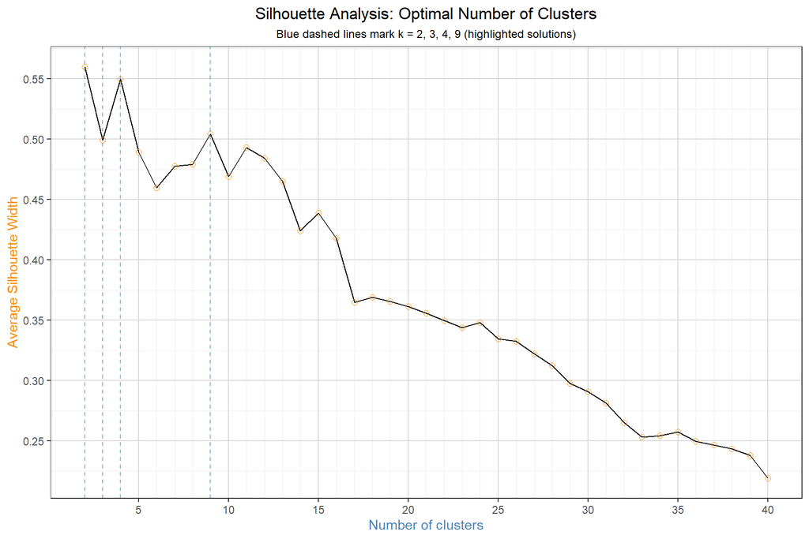

```r
future::plan(future::multisession, workers = N_WORKERS)

sil_width <- c(NA, future_sapply(2:K_MAX, function(k) {
  pam(gower_dist, diss = TRUE, k = k)$silinfo$avg.width
}))

future::plan(future::sequential)

# Silhouette plot -- grid lines, x-ticks every 5
# Drop k=1 (undefined, NA) before plotting to avoid missing-value warnings.
# na.rm = TRUE on geom calls provides an additional safety net.
sil_df <- data.frame(k = seq_len(K_MAX), width = sil_width)
sil_df <- sil_df[!is.na(sil_df$width), ]   # removes k=1 row

ggplot(sil_df, aes(x = k, y = width)) +
  geom_line(colour = "black", na.rm = TRUE) +
  geom_point(colour = "darkorange", shape = 1, size = 2, na.rm = TRUE) +
  geom_vline(xintercept = K_HIGHLIGHT, linetype = "dashed",
             colour = "steelblue", alpha = 0.6) +
  scale_x_continuous(limits       = c(2L, K_MAX),
                     breaks        = seq(5, K_MAX, by = 5),
                     minor_breaks  = seq(2, K_MAX, by = 1)) +
  scale_y_continuous(breaks = scales::pretty_breaks(n = 6)) +
  labs(title    = "Silhouette Analysis: Optimal Number of Clusters",
       subtitle  = sprintf("Blue dashed lines mark k = %s (highlighted solutions)",
                           paste(K_HIGHLIGHT, collapse = ", ")),
       x = "Number of clusters",
       y = "Average Silhouette Width") +
  theme_bw() +
  theme(panel.grid.major = element_line(colour = "grey85"),
        panel.grid.minor = element_line(colour = "grey93"),
        plot.title       = element_text(hjust = 0.5),
        plot.subtitle    = element_text(hjust = 0.5, size = 9),
        axis.title.x     = element_text(colour = "steelblue"),
        axis.title.y     = element_text(colour = "darkorange"))
```

```r
optimal_k <- which.max(sil_width)
cat(sprintf("Optimal k by silhouette: %d  (width = %.4f)\n",
            optimal_k, max(sil_width, na.rm = TRUE)))
```

```
#> Optimal k by silhouette: 2  (width = 0.5597)
```

# 8 Step 4: PAM Fitting and t-SNE Visualisation

## 8.1 t-SNE Embedding

t-distributed Stochastic Neighbor Embedding (t-SNE) is a non-linear dimensionality reduction method that maps high-dimensional pairwise distances to a 2D layout by preserving local neighborhood structure (Maaten and Hinton 2008). Distances in the t-SNE plot are not interpretable in absolute terms — only the relative proximity of points within and between clusters carries meaning — and the same Gower distance matrix is used as input for both PAM and t-SNE to ensure consistency between the clustering and its visualization.

To reiterate, t-SNE is run once on the Gower distance matrix and the resulting 2D coordinates are reused for all k values. This ensures that spatial positions are identical across plots so that differences in cluster boundaries are directly comparable.

Each plot uses three visual layers:

- **Coloured shapes** – PAM cluster assignment.
- **Black cross overlay** – Period 1 (wild-type) sequences.
- **Filled red diamond** – medoid of each cluster: unlike K-Means centroids, PAM medoids are actual observed sequences drawn directly from the data, making them biologically interpretable centers of their cluster.

```r
set.seed(TSNE_SEED)
tsne_obj <- Rtsne(gower_dist, is_distance = TRUE,
                  perplexity = TSNE_PERPLEXITY)

tsne_base <- tsne_obj$Y %>%
  as.data.frame() %>%
  setNames(c("X", "Y")) %>%
  mutate(period = orig_period)
```

## 8.2 VOC SNP Matching Helpers

The following helpers are used throughout Steps 4–8 to count and name VOC defining SNP matches in individual sequences. `count_snp_matches()` returns an integer count; `get_matched_snps()` returns the names of matched SNPs. These functions operate only on the `selected_sites` subset, so overlap counts refer to defining SNPs that were also selected by the entropy GMM.

```r
# ── Helper: count how many of a variant's SNPs are present in a sequence ────
# seq_int: named integer vector (site name -> encoded amino acid value)
# voc:     list with $sites and $snps (from get_variant_snps())
# Returns: integer count of matching SNP alleles
count_snp_matches <- function(seq_int, voc) {
  # Only consider SNP sites that are present in the selected_sites subset
  overlap_sites <- intersect(as.character(voc$sites), names(seq_int))
  if (length(overlap_sites) == 0L) return(0L)

  expected_codes <- vapply(as.integer(overlap_sites), function(s) {
    snp_idx <- which(voc$sites == s)
    aa_char <- substring(voc$snps[snp_idx], nchar(voc$snps[snp_idx]))
    as.integer(encode_aa_sequence(matrix(aa_char))[1L, 1L])
  }, integer(1L))
  names(expected_codes) <- overlap_sites

  sum(vapply(overlap_sites, function(s) {
    isTRUE(seq_int[[s]] == expected_codes[[s]])
  }, logical(1L)))
}

# ── Apply to all Period 1 sequences ─────────────────────────────────────────
# p1_rows_int: row indices into AL_Cat_int that correspond to Period 1
p1_rows_int <- which(orig_period == 1L)

# Build integer version of the deduplicated feature matrix for display/mode calc
AL_Cat_int <- AL_Cat_fac %>%
  mutate_if(is.factor, function(x) as.integer(as.character(x)))

# Convert to named integer matrix for fast row-wise access
AL_Cat_int_mat <- as.matrix(AL_Cat_int)
colnames(AL_Cat_int_mat) <- colnames(AL_Cat_int)

# voc_list <- list(Delta = var_delta, Alpha = var_alpha,
#                  Beta  = var_beta,  Gamma = var_gamma)

# match_counts: matrix [n_p1_int x 4] -- SNP match count per Period 1 sequence
match_counts <- do.call(cbind, lapply(voc_list, function(voc) {
  vapply(p1_rows_int, function(r) {
    count_snp_matches(AL_Cat_int_mat[r, ], voc)
  }, integer(1L))
}))
rownames(match_counts) <- p1_rows_int

# ── Helper: return names of matched SNPs (not just count) ───────────────────
get_matched_snps <- function(seq_int, voc) {
  overlap_sites <- intersect(as.character(voc$sites), names(seq_int))
  if (length(overlap_sites) == 0L) return(character(0L))
  vapply(overlap_sites, function(s) {
    snp_idx   <- which(voc$sites == as.integer(s))
    aa_char   <- substring(voc$snps[snp_idx], nchar(voc$snps[snp_idx]))
    exp_code  <- as.integer(encode_aa_sequence(matrix(aa_char))[1L, 1L])
    if (isTRUE(seq_int[[s]] == exp_code)) voc$snps[snp_idx] else NA_character_
  }, character(1L)) |> (\(x) x[!is.na(x)])()
}

# ── Summary table with SNP detail ───────────────────────────────────────────
cat("Period 1 sequences by number of VOC SNP matches\n")
```

```
#> Period 1 sequences by number of VOC SNP matches
```

```r
cat("(only SNPs at GMM-selected sites are considered)\n\n")
```

```
#> (only SNPs at GMM-selected sites are considered)
```

```r
for (voc_nm in names(voc_list)) {
  voc         <- voc_list[[voc_nm]]
  n_overlap   <- length(intersect(as.character(voc$sites),
                                  as.character(selected_sites)))
  counts      <- match_counts[, voc_nm]
  cat(sprintf("%s  (%d defining SNPs, %d overlap with selected sites):\n",
              voc_nm, length(voc$sites), n_overlap))
  if (n_overlap == 0L) {
    cat("  No overlap with GMM-selected sites -- skip.\n\n")
    next
  }
  for (m in seq(n_overlap, 0L)) {
    seq_idx <- which(counts == m)
    if (length(seq_idx) == 0L && m < n_overlap) next
    cat(sprintf("  %d/%d SNP match(es): %d sequence(s)",
                m, n_overlap, length(seq_idx)))
    if (m > 0L && length(seq_idx) > 0L) {
      # Collect matched SNP names for each sequence at this tier
      snp_sets <- lapply(p1_rows_int[seq_idx], function(r) {
        get_matched_snps(AL_Cat_int_mat[r, ], voc)
      })
      # Unique SNP patterns
      snp_patterns <- sort(unique(vapply(snp_sets,
                                         paste, character(1L), collapse = "+")))
      cat(sprintf("  [SNP pattern(s): %s]", paste(snp_patterns, collapse = " | ")))
    }
    cat("\n")
  }
  cat("\n")
}
```

```
#> Delta  (5 defining SNPs, 5 overlap with selected sites):
#>   5/5 SNP match(es): 0 sequence(s)
#>   1/5 SNP match(es): 1 sequence(s)  [SNP pattern(s): D950N]
#>   0/5 SNP match(es): 35 sequence(s)
#>
#> Alpha  (6 defining SNPs, 2 overlap with selected sites):
#>   2/2 SNP match(es): 0 sequence(s)
#>   1/2 SNP match(es): 1 sequence(s)  [SNP pattern(s): P681H]
#>   0/2 SNP match(es): 35 sequence(s)
#>
#> Beta  (6 defining SNPs, 4 overlap with selected sites):
#>   4/4 SNP match(es): 0 sequence(s)
#>   0/4 SNP match(es): 36 sequence(s)
#>
#> Gamma  (10 defining SNPs, 10 overlap with selected sites):
#>   10/10 SNP match(es): 0 sequence(s)
#>   1/10 SNP match(es): 3 sequence(s)  [SNP pattern(s): D138Y | H655Y | L18F]
#>   0/10 SNP match(es): 33 sequence(s)
```

## 8.3 t-SNE Plot Function

A reusable helper that renders the t-SNE embedding coloured by PAM cluster assignment. Three visual layers are overlaid: cluster-coloured points, black crosses for Period 1 sequences, and red diamonds for cluster medoids.

```r
# Reusable plot function: takes PAM clustering vector and medoid row indices,
# produces a t-SNE plot with three visual layers:
#   1. Coloured shapes by cluster
#   2. Black cross overlay for Period 1 (wild-type) sequences
#   3. Filled red diamond for each cluster medoid
plot_tsne <- function(pam_clust, k, medoid_rows,
                      tsne_df    = tsne_base,
                      period_vec = orig_period,
                      xlim_fixed = NULL,
                      ylim_fixed = NULL) {

  df <- tsne_df %>%
    mutate(cluster   = factor(pam_clust),
           is_p1     = (period_vec == 1L),
           is_medoid = row_number() %in% medoid_rows)

  p <- ggplot(df, aes(x = X, y = Y, colour = cluster, shape = cluster)) +
    geom_point(size = 2, alpha = 0.7) +
    scale_shape_manual(values = seq(0, k)) +
    # Black cross overlay for all Period 1 sequences
    geom_point(data         = subset(df, is_p1),
               aes(x = X, y = Y),
               colour       = "black", shape = 4, size = 2,
               inherit.aes  = FALSE) +
    # Semi-transparent red diamond: alpha reveals the medoid is a real data point.
    geom_point(data         = subset(df, is_medoid),
               aes(x = X, y = Y),
               colour       = "red", shape = 18, size = 5,
               alpha        = 0.45,
               inherit.aes  = FALSE) +
    labs(title    = sprintf("PAM k = %d  |  t-SNE visualisation", k),
         subtitle = "Crosses = Period 1 (wild-type);  Red diamonds = cluster medoids",
         x = "t-SNE dimension 1",
         y = "t-SNE dimension 2") +
    theme_bw() +
    theme(plot.title    = element_text(hjust = 0.5),
          plot.subtitle = element_text(hjust = 0.5, size = 9))

  # Apply fixed axis ranges if supplied -- ensures identical plot area across
  # all k values regardless of legend size differences
  if (!is.null(xlim_fixed) && !is.null(ylim_fixed))
    p <- p + coord_cartesian(xlim = xlim_fixed, ylim = ylim_fixed)

  print(p)
  invisible(p)
}
```

## 8.4 PAM and Medoid Analysis

```r
# Helper: render kableExtra table in results='asis' chunks inside loops
kt <- function(tbl) cat(as.character(tbl), "\n")
# Fit PAM for all highlighted k values
pam_fits <- lapply(K_HIGHLIGHT, function(k) {
  pam(gower_dist, diss = TRUE, k = k)
})
names(pam_fits) <- paste0("k", K_HIGHLIGHT)

# Precompute fixed axis ranges from the common t-SNE coordinates so that all
# plots have an identical data area regardless of legend size differences.
x_pad    <- diff(range(tsne_base$X)) * 0.05
y_pad    <- diff(range(tsne_base$Y)) * 0.05
xlim_fix <- range(tsne_base$X) + c(-x_pad, x_pad)
ylim_fix <- range(tsne_base$Y) + c(-y_pad, y_pad)

for (k in K_HIGHLIGHT) {
  fit         <- pam_fits[[paste0("k", k)]]
  medoid_rows <- fit$id.med

  # ── Subsection heading ──────────────────────────────────────────────────
  cat(sprintf("\n## PAM k = %d\n\n### t-SNE Plot\n\n", k))

  # ── Plot ─────────────────────────────────────────────────────────────────
  plot_tsne(fit$clustering, k, medoid_rows,
            xlim_fixed = xlim_fix, ylim_fixed = ylim_fix)

  # ── Medoid sequences kable ───────────────────────────────────────────────
  cat(sprintf("\n### Medoid Sequences (k = %d)\n\n", k))
  medoid_aa <- decode_aa_sequence(
    as.matrix(AL_Cat_int[medoid_rows, , drop = FALSE])
  )
  medoid_df           <- as.data.frame(medoid_aa)
  colnames(medoid_df) <- as.character(selected_sites)
  rownames(medoid_df) <- paste0("cl_", seq_len(k))

  # Red cell_spec wherever cl_i (i > 1) differs from cl_1 at that site.
  # Direct [row, col_name] access -- avoids any as.character(df[row,]) pitfalls.
  if (k > 1L) {
    for (ri in 2L:k) {
      for (nm in colnames(medoid_df)) {
        v1 <- medoid_df[1L, nm]; vi <- medoid_df[ri, nm]
        if (vi != v1)
          medoid_df[ri, nm] <- cell_spec(vi, format = "html",
                                         color = "red", bold = TRUE)
      }
    }
  }

  kt(
    kbl(medoid_df, format = "html", escape = FALSE,
        caption = sprintf("Medoid sequences (k = %d) | red = differs from cl_1", k)) |>
      kable_styling(bootstrap_options = c("condensed", "hover"),
                    font_size = 11, full_width = FALSE) |>
      row_spec(1L, background = "#d6eaf8")
  )

  # ── VOC SNP content kable ────────────────────────────────────────────────
  cat(sprintf("\n### VOC SNP Content of Medoids (k = %d)\n\n", k))

  voc_tbl <- do.call(rbind, lapply(seq_len(k), function(cl_i) {
    row_i <- medoid_rows[cl_i]
    vapply(names(voc_list), function(voc_nm) {
      voc   <- voc_list[[voc_nm]]
      n_ov  <- length(intersect(as.character(voc$sites),
                                as.character(selected_sites)))
      n_m   <- count_snp_matches(AL_Cat_int_mat[row_i, ], voc)
      sprintf("%d / %d", n_m, n_ov)
    }, character(1L))
  }))
  voc_tbl           <- as.data.frame(voc_tbl)
  rownames(voc_tbl) <- paste0("cl_", seq_len(k))

  kt(
    kbl(voc_tbl, format = "html",
        caption = sprintf("VOC SNP matches per medoid (matched / overlap sites), k = %d", k)) |>
      kable_styling(bootstrap_options = c("condensed", "hover"),
                    font_size = 11, full_width = FALSE)
  )
  cat("\n")
}
```

## 8.5 PAM k = 2

### 8.5.1 t-SNE Plot

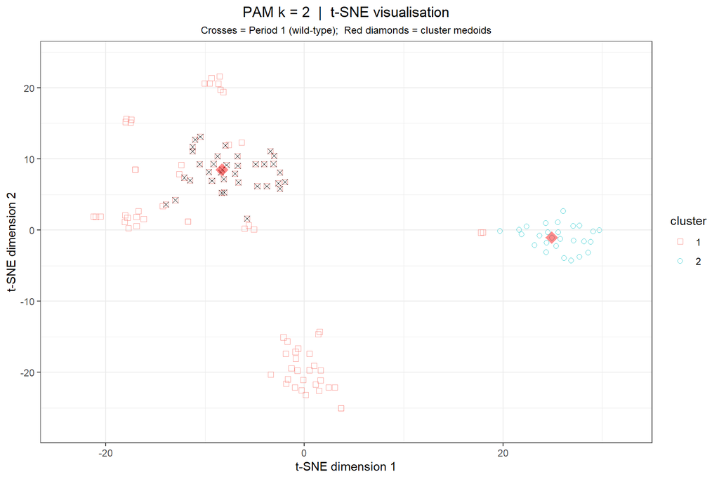

### Medoid Sequences (k = 2)

Medoid sequences (k = 2) | red = differs from cl_1

|  | 5 | 18 | 19 | 20 | 26 | 54 | 95 | 138 | 141 | 142 | 144 | 152 | 153 | 155 | 157 | 158 | 180 | 183 | 190 | 253 | 417 | 452 | 477 | 478 | 484 | 501 | 520 | 614 | 655 | … |
| --- | --- | --- | --- | --- | --- | --- | --- | --- | --- | --- | --- | --- | --- | --- | --- | --- | --- | --- | --- | --- | --- | --- | --- | --- | --- | --- | --- | --- | --- | --- |
| cl_1 | L | L | T | T | P | L | T | D | L | G | Y | W | M | S | F | R | E | Q | R | D | K | L | S | T | E | N | A | G | H | … |
| cl_2 | L | F | T | N | S | L | T | Y | L | G | Y | W | M | S | F | R | E | Q | S | D | T | L | S | T | K | Y | A | G | Y | … |

### 8.5.2 VOC SNP Content of Medoids (k = 2)

VOC SNP matches per medoid (matched / overlap sites), k = 2

|  | Delta | Alpha | Beta | Gamma |
| --- | --- | --- | --- | --- |
| cl_1 | 0 / 5 | 0 / 2 | 0 / 4 | 0 / 10 |
| cl_2 | 0 / 5 | 1 / 2 | 2 / 4 | 10 / 10 |

## 8.6 PAM k = 3

### 8.6.1 t-SNE Plot

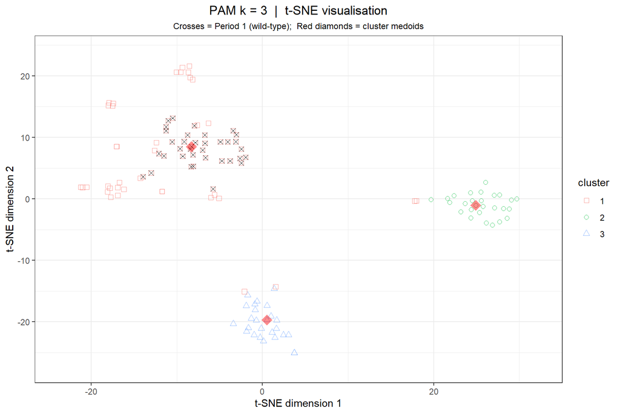

### Medoid Sequences (k = 3)

Medoid sequences (k = 3) | red = differs from cl_1

|  | 5 | 18 | 19 | 20 | 26 | 54 | 95 | 138 | 141 | 142 | 144 | 152 | 153 | 155 | 157 | 158 | 180 | 183 | 190 | 253 | 417 | 452 | 477 | 478 | 484 | 501 | 520 | 614 | 655 | … |
| --- | --- | --- | --- | --- | --- | --- | --- | --- | --- | --- | --- | --- | --- | --- | --- | --- | --- | --- | --- | --- | --- | --- | --- | --- | --- | --- | --- | --- | --- | --- |
| cl_1 | L | L | T | T | P | L | T | D | L | G | Y | W | M | S | F | R | E | Q | R | D | K | L | S | T | E | N | A | G | H | … |
| cl_2 | L | F | T | N | S | L | T | Y | L | G | Y | W | M | S | F | R | E | Q | S | D | T | L | S | T | K | Y | A | G | Y | … |
| cl_3 | L | L | R | T | P | L | T | D | L | G | Y | W | M | S | F | G | E | Q | R | D | K | R | S | K | E | N | A | G | H | … |

### 8.6.2 VOC SNP Content of Medoids (k = 3)

VOC SNP matches per medoid (matched / overlap sites), k = 3

|  | Delta | Alpha | Beta | Gamma |
| --- | --- | --- | --- | --- |
| cl_1 | 0 / 5 | 0 / 2 | 0 / 4 | 0 / 10 |
| cl_2 | 0 / 5 | 1 / 2 | 2 / 4 | 10 / 10 |
| cl_3 | 5 / 5 | 0 / 2 | 0 / 4 | 0 / 10 |

## 8.7 PAM k = 4

### 8.7.1 t-SNE Plot

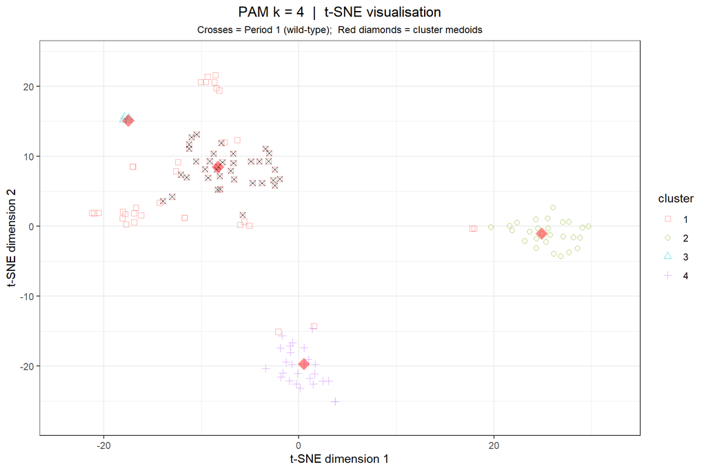

### Medoid Sequences (k = 4)

Medoid sequences (k = 4) | red = differs from cl_1

|  | 5 | 18 | 19 | 20 | 26 | 54 | 95 | 138 | 141 | 142 | 144 | 152 | 153 | 155 | 157 | 158 | 180 | 183 | 190 | 253 | 417 | 452 | 477 | 478 | 484 | 501 | 520 | 614 | 655 | … |
| --- | --- | --- | --- | --- | --- | --- | --- | --- | --- | --- | --- | --- | --- | --- | --- | --- | --- | --- | --- | --- | --- | --- | --- | --- | --- | --- | --- | --- | --- | --- |
| cl_1 | L | L | T | T | P | L | T | D | L | G | Y | W | M | S | F | R | E | Q | R | D | K | L | S | T | E | N | A | G | H | … |
| cl_2 | L | F | T | N | S | L | T | Y | L | G | Y | W | M | S | F | R | E | Q | S | D | T | L | S | T | K | Y | A | G | Y | … |
| cl_3 | L | L | T | T | P | L | T | D | Y | Y | K | S | E | R | Y | S | Q | F | V | D | K | R | S | T | E | N | A | G | H | … |
| cl_4 | L | L | R | T | P | L | T | D | L | G | Y | W | M | S | F | G | E | Q | R | D | K | R | S | K | E | N | A | G | H | … |

### 8.7.2 VOC SNP Content of Medoids (k = 4)

VOC SNP matches per medoid (matched / overlap sites), k = 4

|  | Delta | Alpha | Beta | Gamma |
| --- | --- | --- | --- | --- |
| cl_1 | 0 / 5 | 0 / 2 | 0 / 4 | 0 / 10 |
| cl_2 | 0 / 5 | 1 / 2 | 2 / 4 | 10 / 10 |
| cl_3 | 1 / 5 | 0 / 2 | 0 / 4 | 0 / 10 |
| cl_4 | 5 / 5 | 0 / 2 | 0 / 4 | 0 / 10 |

## 8.8 PAM k = 9

### 8.8.1 t-SNE Plot

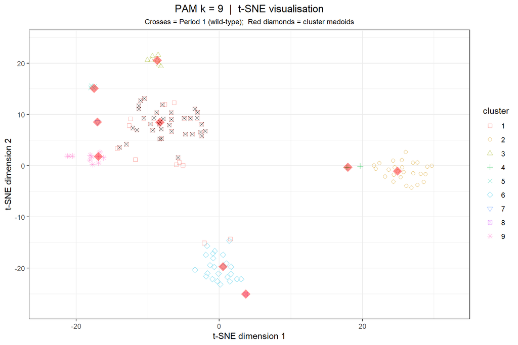

### Medoid Sequences (k = 9)

Medoid sequences (k = 9) | red = differs from cl_1

|  | 5 | 18 | 19 | 20 | 26 | 54 | 95 | 138 | 141 | 142 | 144 | 152 | 153 | 155 | 157 | 158 | 180 | 183 | 190 | 253 | 417 | 452 | 477 | 478 | 484 | 501 | 520 | 614 | 655 | … |
| --- | --- | --- | --- | --- | --- | --- | --- | --- | --- | --- | --- | --- | --- | --- | --- | --- | --- | --- | --- | --- | --- | --- | --- | --- | --- | --- | --- | --- | --- | --- |
| cl_1 | L | L | T | T | P | L | T | D | L | G | Y | W | M | S | F | R | E | Q | R | D | K | L | S | T | E | N | A | G | H | … |
| cl_2 | L | F | T | N | S | L | T | Y | L | G | Y | W | M | S | F | R | E | Q | S | D | T | L | S | T | K | Y | A | G | Y | … |
| cl_3 | F | L | T | T | P | L | I | D | L | G | Y | W | M | S | F | R | E | Q | R | G | K | L | N | T | E | N | A | G | H | … |
| cl_4 | L | F | T | N | S | L | T | Y | L | G | Y | W | M | S | F | R | E | Q | R | D | K | R | S | K | E | N | A | G | H | … |
| cl_5 | L | L | T | T | P | L | T | D | Y | Y | K | S | E | R | Y | S | Q | F | V | D | K | R | S | T | E | N | A | G | H | … |
| cl_6 | L | L | R | T | P | L | T | D | L | G | Y | W | M | S | F | G | E | Q | R | D | K | R | S | K | E | N | A | G | H | … |
| cl_7 | L | L | T | T | S | L | T | D | L | G | Y | W | T | S | S | R | E | Q | R | D | K | L | N | T | K | N | A | G | Y | … |
| cl_8 | L | L | R | T | P | L | T | C | P | F | D | K | S | M | S | G | E | Q | R | D | K | R | S | K | E | N | A | G | H | … |
| cl_9 | L | L | T | T | P | L | T | D | L | G | Y | W | M | S | F | R | E | Q | R | D | K | L | S | T | E | Y | A | G | H | … |

### 8.8.2 VOC SNP Content of Medoids (k = 9)

VOC SNP matches per medoid (matched / overlap sites), k = 9

|  | Delta | Alpha | Beta | Gamma |
| --- | --- | --- | --- | --- |
| cl_1 | 0 / 5 | 0 / 2 | 0 / 4 | 0 / 10 |
| cl_2 | 0 / 5 | 1 / 2 | 2 / 4 | 10 / 10 |
| cl_3 | 0 / 5 | 0 / 2 | 1 / 4 | 0 / 10 |
| cl_4 | 3 / 5 | 0 / 2 | 0 / 4 | 5 / 10 |
| cl_5 | 1 / 5 | 0 / 2 | 0 / 4 | 0 / 10 |
| cl_6 | 5 / 5 | 0 / 2 | 0 / 4 | 0 / 10 |
| cl_7 | 0 / 5 | 1 / 2 | 1 / 4 | 3 / 10 |
| cl_8 | 5 / 5 | 0 / 2 | 0 / 4 | 0 / 10 |
| cl_9 | 0 / 5 | 2 / 2 | 1 / 4 | 1 / 10 |

# 9 Step 5: Modal Amino Acid Profile per Cluster

For each k value, we compute the most frequent (modal) amino acid at each GMM-selected site within each cluster. This reveals the characteristic sequence signature of each temporal group and allows direct comparison with the medoid. The mode matrices computed here are also used by the contrast analysis in Step 7.

```r
get_mode <- function(x) { ux <- unique(x); ux[which.max(tabulate(match(x, ux)))] }

# Store mode matrices for Step 7 contrast analysis.
mode_results <- list()

for (k in K_HIGHLIGHT) {
  fit         <- pam_fits[[paste0("k", k)]]
  clust_vec   <- fit$clustering
  medoid_rows <- fit$id.med
  k_levels    <- sort(unique(clust_vec))

  mode_mat <- do.call(rbind, lapply(k_levels, function(cl) {
    rows <- which(clust_vec == cl)
    vapply(colnames(AL_Cat_int), function(s) get_mode(AL_Cat_int[rows, s]),
           integer(1L))
  }))
  rownames(mode_mat) <- paste0("cl_", k_levels)
  colnames(mode_mat) <- colnames(AL_Cat_int)

  mode_aa           <- decode_aa_sequence(as.matrix(mode_mat))
  rownames(mode_aa) <- paste0("cl_", k_levels)
  colnames(mode_aa) <- as.character(selected_sites)

  medoid_int          <- as.matrix(AL_Cat_int[medoid_rows, , drop = FALSE])
  medoid_aa           <- decode_aa_sequence(medoid_int)
  rownames(medoid_aa) <- paste0("med_", k_levels)
  colnames(medoid_aa) <- as.character(selected_sites)

  mode_results[[paste0("k", k)]] <- list(
    mode_int  = mode_mat, k_levels = k_levels, clust_vec = clust_vec)

  same_flag <- all(mode_mat == medoid_int)
  obs_note  <- if (same_flag)
    sprintf("**Mode = Medoid for all clusters (k = %d): tight cohesion confirmed.**", k)
  else {
    diff_s <- which(apply(mode_mat != medoid_int, 2, any))
    sprintf("**Sites where mode differs from medoid (k = %d): %s**",
            k, paste(selected_sites[diff_s], collapse = ", "))
  }

  cat(sprintf("\n### k = %d\n\n%s\n\n", k, obs_note))

  # Build combined df with cell_spec red highlighting where mode != medoid
  combined_df <- as.data.frame(rbind(mode_aa, medoid_aa), stringsAsFactors = FALSE)
  n_cl <- length(k_levels)
  for (col_i in seq_along(selected_sites)) {
    col_nm <- as.character(selected_sites[col_i])
    for (ci in seq_along(k_levels)) {
      mv <- mode_aa[ci, col_i]; dv <- medoid_aa[ci, col_i]
      if (mv != dv) {
        combined_df[ci,        col_nm] <- cell_spec(mv, color="red", bold=TRUE)
        combined_df[n_cl + ci, col_nm] <- cell_spec(dv, color="red", bold=TRUE)
      }
    }
  }

  kt(
    kbl(combined_df, format="html", escape=FALSE,
        caption=sprintf("Mode (cl_* = blue) / Medoid (med_* = yellow) | red = differs  [k=%d]", k)) |>
      kable_styling(bootstrap_options=c("condensed","hover"), font_size=11, full_width=FALSE) |>
      row_spec(seq_len(n_cl),           background="#d6eaf8") |>
      row_spec(seq(n_cl+1L, n_cl*2L),   background="#fef9e7")
  )
  cat("\n")
}
```

### 9.0.1 k = 2

**Mode = Medoid for all clusters (k = 2): tight cohesion confirmed.**

Mode (cl_* = blue) / Medoid (med_* = yellow) | red = differs [k=2]

|  | 5 | 18 | 19 | 20 | 26 | 54 | 95 | 138 | 141 | 142 | 144 | 152 | 153 | 155 | 157 | 158 | 180 | 183 | 190 | 253 | 417 | 452 | 477 | 478 | 484 | 501 | 520 | 614 | 655 | … |
| --- | --- | --- | --- | --- | --- | --- | --- | --- | --- | --- | --- | --- | --- | --- | --- | --- | --- | --- | --- | --- | --- | --- | --- | --- | --- | --- | --- | --- | --- | --- |
| cl_1 | L | L | T | T | P | L | T | D | L | G | Y | W | M | S | F | R | E | Q | R | D | K | L | S | T | E | N | A | G | H | … |
| cl_2 | L | F | T | N | S | L | T | Y | L | G | Y | W | M | S | F | R | E | Q | S | D | T | L | S | T | K | Y | A | G | Y | … |
| med_1 | L | L | T | T | P | L | T | D | L | G | Y | W | M | S | F | R | E | Q | R | D | K | L | S | T | E | N | A | G | H | … |
| med_2 | L | F | T | N | S | L | T | Y | L | G | Y | W | M | S | F | R | E | Q | S | D | T | L | S | T | K | Y | A | G | Y | … |

### 9.0.2 k = 3

**Mode = Medoid for all clusters (k = 3): tight cohesion confirmed.**

Mode (cl_* = blue) / Medoid (med_* = yellow) | red = differs [k=3]

|  | 5 | 18 | 19 | 20 | 26 | 54 | 95 | 138 | 141 | 142 | 144 | 152 | 153 | 155 | 157 | 158 | 180 | 183 | 190 | 253 | 417 | 452 | 477 | 478 | 484 | 501 | 520 | 614 | 655 | … |
| --- | --- | --- | --- | --- | --- | --- | --- | --- | --- | --- | --- | --- | --- | --- | --- | --- | --- | --- | --- | --- | --- | --- | --- | --- | --- | --- | --- | --- | --- | --- |
| cl_1 | L | L | T | T | P | L | T | D | L | G | Y | W | M | S | F | R | E | Q | R | D | K | L | S | T | E | N | A | G | H | … |
| cl_2 | L | F | T | N | S | L | T | Y | L | G | Y | W | M | S | F | R | E | Q | S | D | T | L | S | T | K | Y | A | G | Y | … |
| cl_3 | L | L | R | T | P | L | T | D | L | G | Y | W | M | S | F | G | E | Q | R | D | K | R | S | K | E | N | A | G | H | … |
| med_1 | L | L | T | T | P | L | T | D | L | G | Y | W | M | S | F | R | E | Q | R | D | K | L | S | T | E | N | A | G | H | … |
| med_2 | L | F | T | N | S | L | T | Y | L | G | Y | W | M | S | F | R | E | Q | S | D | T | L | S | T | K | Y | A | G | Y | … |
| med_3 | L | L | R | T | P | L | T | D | L | G | Y | W | M | S | F | G | E | Q | R | D | K | R | S | K | E | N | A | G | H | … |

### 9.0.3 k = 4

**Mode = Medoid for all clusters (k = 4): tight cohesion confirmed.**

Mode (cl_* = blue) / Medoid (med_* = yellow) | red = differs [k=4]

|  | 5 | 18 | 19 | 20 | 26 | 54 | 95 | 138 | 141 | 142 | 144 | 152 | 153 | 155 | 157 | 158 | 180 | 183 | 190 | 253 | 417 | 452 | 477 | 478 | 484 | 501 | 520 | 614 | 655 | … |
| --- | --- | --- | --- | --- | --- | --- | --- | --- | --- | --- | --- | --- | --- | --- | --- | --- | --- | --- | --- | --- | --- | --- | --- | --- | --- | --- | --- | --- | --- | --- |
| cl_1 | L | L | T | T | P | L | T | D | L | G | Y | W | M | S | F | R | E | Q | R | D | K | L | S | T | E | N | A | G | H | … |
| cl_2 | L | F | T | N | S | L | T | Y | L | G | Y | W | M | S | F | R | E | Q | S | D | T | L | S | T | K | Y | A | G | Y | … |
| cl_3 | L | L | T | T | P | L | T | D | Y | Y | K | S | E | R | Y | S | Q | F | V | D | K | R | S | T | E | N | A | G | H | … |
| cl_4 | L | L | R | T | P | L | T | D | L | G | Y | W | M | S | F | G | E | Q | R | D | K | R | S | K | E | N | A | G | H | … |
| med_1 | L | L | T | T | P | L | T | D | L | G | Y | W | M | S | F | R | E | Q | R | D | K | L | S | T | E | N | A | G | H | … |
| med_2 | L | F | T | N | S | L | T | Y | L | G | Y | W | M | S | F | R | E | Q | S | D | T | L | S | T | K | Y | A | G | Y | … |
| med_3 | L | L | T | T | P | L | T | D | Y | Y | K | S | E | R | Y | S | Q | F | V | D | K | R | S | T | E | N | A | G | H | … |
| med_4 | L | L | R | T | P | L | T | D | L | G | Y | W | M | S | F | G | E | Q | R | D | K | R | S | K | E | N | A | G | H | … |

### 9.0.4 k = 9

**Sites where mode differs from medoid (k = 9): 26, 144, 190**

Mode (cl_* = blue) / Medoid (med_* = yellow) | red = differs [k=9]

|  | 5 | 18 | 19 | 20 | 26 | 54 | 95 | 138 | 141 | 142 | 144 | 152 | 153 | 155 | 157 | 158 | 180 | 183 | 190 | 253 | 417 | 452 | 477 | 478 | 484 | 501 | 520 | 614 | 655 | … |
| --- | --- | --- | --- | --- | --- | --- | --- | --- | --- | --- | --- | --- | --- | --- | --- | --- | --- | --- | --- | --- | --- | --- | --- | --- | --- | --- | --- | --- | --- | --- |
| cl_1 | L | L | T | T | P | L | T | D | L | G | Y | W | M | S | F | R | E | Q | R | D | K | L | S | T | E | N | A | G | H | … |
| cl_2 | L | F | T | N | S | L | T | Y | L | G | Y | W | M | S | F | R | E | Q | S | D | T | L | S | T | K | Y | A | G | Y | … |
| cl_3 | F | L | T | T | P | L | I | D | L | G | Y | W | M | S | F | R | E | Q | R | G | K | L | N | T | E | N | A | G | H | … |
| cl_4 | L | F | T | N | S | L | T | Y | L | G | Y | W | M | S | F | R | E | Q | S | D | K | R | S | K | E | N | A | G | H | … |
| cl_5 | L | L | T | T | P | L | T | D | Y | Y | K | S | E | R | Y | S | Q | F | V | D | K | R | S | T | E | N | A | G | H | … |
| cl_6 | L | L | R | T | P | L | T | D | L | G | Y | W | M | S | F | G | E | Q | R | D | K | R | S | K | E | N | A | G | H | … |
| cl_7 | L | L | T | T | P | L | T | D | L | G | Y | W | T | S | S | R | E | Q | R | D | K | L | N | T | K | N | A | G | Y | … |
| cl_8 | L | L | R | T | P | L | T | C | P | F | G | K | S | M | S | G | E | Q | R | D | K | R | S | K | E | N | A | G | H | … |
| cl_9 | L | L | T | T | P | L | T | D | L | G | Y | W | M | S | F | R | E | Q | R | D | K | L | S | T | E | Y | A | G | H | … |
| med_1 | L | L | T | T | P | L | T | D | L | G | Y | W | M | S | F | R | E | Q | R | D | K | L | S | T | E | N | A | G | H | … |
| med_2 | L | F | T | N | S | L | T | Y | L | G | Y | W | M | S | F | R | E | Q | S | D | T | L | S | T | K | Y | A | G | Y | … |
| med_3 | F | L | T | T | P | L | I | D | L | G | Y | W | M | S | F | R | E | Q | R | G | K | L | N | T | E | N | A | G | H | … |
| med_4 | L | F | T | N | S | L | T | Y | L | G | Y | W | M | S | F | R | E | Q | R | D | K | R | S | K | E | N | A | G | H | … |
| med_5 | L | L | T | T | P | L | T | D | Y | Y | K | S | E | R | Y | S | Q | F | V | D | K | R | S | T | E | N | A | G | H | … |
| med_6 | L | L | R | T | P | L | T | D | L | G | Y | W | M | S | F | G | E | Q | R | D | K | R | S | K | E | N | A | G | H | … |
| med_7 | L | L | T | T | S | L | T | D | L | G | Y | W | T | S | S | R | E | Q | R | D | K | L | N | T | K | N | A | G | Y | … |
| med_8 | L | L | R | T | P | L | T | C | P | F | D | K | S | M | S | G | E | Q | R | D | K | R | S | K | E | N | A | G | H | … |
| med_9 | L | L | T | T | P | L | T | D | L | G | Y | W | M | S | F | R | E | Q | R | D | K | L | S | T | E | Y | A | G | H | … |

> **Observation.** Across k = 2, 3 and 4, the modal amino acid at every selected site within each cluster coincides exactly with the PAM medoid sequence. This agreement confirms that each cluster is internally homogeneous: the most centrally located sequence in Gower space is also the most frequent sequence at every position, which is precisely what one expects from a viral population dominated by a single emergent haplotype. At k = 9 the correspondence is no longer exact at every site, reflecting the finer subdivision of sequence space into smaller, less internally uniform clusters. The overall mutational profile of each medoid nonetheless remains intact, indicating that the core variant signal is preserved even as the clustering resolution increases.

# 10 Step 6: Precision, Recall and F1 Score

For each k value tested (2, 3, 4 and 9), we compute classification metrics treating Period 1 sequences as the positive class. Since PAM cluster labels are arbitrary integers, we first identify the cluster with the highest Period 1 purity and designate that as the predicted positive label.

```r
compute_metrics <- function(clust_vec, period_vec, n_p1_eff) {
  p1_idx <- which(period_vec == 1L)
  cl_purity <- tapply(clust_vec[p1_idx], clust_vec[p1_idx], length)
  positive_cluster <- as.integer(names(which.max(cl_purity)))
  pred_positive <- clust_vec == positive_cluster
  true_positive <- period_vec == 1L
  TP <- sum( pred_positive &  true_positive)
  FP <- sum( pred_positive & !true_positive)
  FN <- sum(!pred_positive &  true_positive)
  TN <- sum(!pred_positive & !true_positive)
  precision <- if ((TP + FP) > 0) TP / (TP + FP) else NA_real_
  recall    <- if ((TP + FN) > 0) TP / (TP + FN) else NA_real_
  f1        <- if (!is.na(precision) && !is.na(recall) && (precision + recall) > 0)
               2 * precision * recall / (precision + recall) else NA_real_
  list(k = length(unique(clust_vec)), positive_cluster = positive_cluster,
       TP = TP, FP = FP, FN = FN, TN = TN,
       precision = round(precision, 4), recall = round(recall, 4),
       f1 = round(f1, 4))
}

metrics_list <- lapply(K_HIGHLIGHT, function(k) {
  compute_metrics(pam_fits[[paste0("k", k)]]$clustering, orig_period, n_p1_eff)
})
metrics_df <- do.call(rbind, lapply(metrics_list, as.data.frame))
print(metrics_df)
```

```
#>   k positive_cluster TP FP FN TN precision recall     f1
#> 1 2                1 36 64  0 27    0.3600      1 0.5294
#> 2 3                1 36 38  0 53    0.4865      1 0.6545
#> 3 4                1 36 34  0 57    0.5143      1 0.6792
#> 4 9                1 36 12  0 79    0.7500      1 0.8571
```

> **On the interplay between statistical optimality and biological knowledge.** The silhouette analysis provides a useful unsupervised criterion for cluster compactness and separation. It correctly identifies k = 2 as the most statistically compact solution. However, k = 2 conflates all non-ancestral variants into a single cluster, obscuring the variant-level structure that is biologically meaningful. As k increases to 3 and 4, F1 scores improve and individual VOC-associated clusters become identifiable, which is confirmed visually through t-SNE, quantitatively through the medoid SNP content tables, and formally through precision and recall. Practitioners working with biological sequence data should treat silhouette analysis as a starting point, not a definitive criterion: statistical optimality and biological interpretability need not coincide. Selecting k requires integrating three complementary sources of evidence: the silhouette curve, visual inspection of the t-SNE layout, and domain knowledge. No single criterion is sufficient on its own.

# 11 Step 7: Site Differentiation — Wild-Type Cluster vs Later Clusters

Using the mode matrices computed in Step 5, we ask: at which Spike sites does the modal amino acid in each non-wild-type cluster differ from that of the wild-type cluster?

## 11.1 Annotation helper

```r
# annotate_site_full(s): compact VOC annotation for Spike site s.
# Uses ALL 12 variants in sarscov2_variants (not just the 4 in voc_list).
# Distinguishes:
#   "VOC-SNP"  = site is a defining SNP for that VOC (Defining_SNP_Sites)
#   "VOC"      = site is mutated in that VOC but is NOT a defining SNP
#   ""         = not found in any VOC catalogue
# Examples: 452 -> "Alpha/Delta/Epsilon/Iota/Kappa-SNP"
#            95 -> "Delta/Iota/Kappa/Omicron"
#           190 -> "Gamma-SNP; Iota"
annotate_site_full <- function(s) {
  labels    <- unlist(sarscov2_variants$WHO_Label)
  snp_sites <- sarscov2_variants$Defining_SNP_Sites
  mut_sites <- sarscov2_variants$Mutation_Sites
  snp_vocs  <- labels[vapply(snp_sites, function(ss) s %in% ss, logical(1L))]
  mut_only  <- setdiff(labels[vapply(mut_sites, function(ms) s %in% ms, logical(1L))],
                       snp_vocs)
  parts <- c(
    if (length(snp_vocs) > 0L) paste0(paste(snp_vocs, collapse = "/"), "-SNP"),
    if (length(mut_only)  > 0L) paste(mut_only, collapse = "/"))
  if (length(parts) == 0L) "" else paste(parts, collapse = "; ")
}
```